# Data 607 - Final Project

## Introduction

We have chosen to investigate the coronavirus data set provided by John Hopkins University which themselves source the data from DXY, an online platform run by members of the Chinese medical community.

We combine this data with data sourced through the API of Numbeo which provides country information on various indicators, including health care and quality of life.

Our goal is to investigate wether we can identify any correlation between any of these indicators and either the mortality rate (i.e. death per confirmed case) or the death per capita.

## Loading required libraries

We load all required libraries:

```r
library(httr)
library(dplyr)
library(tidyr)
library(ggplot2)
library(knitr)
library(date)
library(tidyverse)
library(jsonlite)
library(kableExtra)
```

## Downloading Covid-19 Data

We download three seperate CSV (for confirmed cases, recoveries and deaths) from the John Hopkins GitHub account and save them as data frames:

```r
urlRemote  <- "https://raw.githubusercontent.com/"
pathGithub <- "CSSEGISandData/COVID-19/master/csse_covid_19_data/csse_covid_19_time_series/"
```

```r
fileConfirmGlobal <- "time_series_covid19_confirmed_global.csv"
fileDeathsGlobal <- "time_series_covid19_deaths_global.csv"
fileRecovGlobal <- "time_series_covid19_recovered_global.csv"
```

```r
confsGlobal <- read.csv(paste0(urlRemote, pathGithub, fileConfirmGlobal),header = TRUE)
deathsGlobal <- read.csv(paste0(urlRemote, pathGithub, fileDeathsGlobal),header = TRUE)
recovsGlobal<- read.csv(paste0(urlRemote, pathGithub, fileRecovGlobal),header = TRUE)
```

## Downloading Country Population

We download data which includes population size, ISO2 and ISO3 codes per country to later be able to merge it with other country indices

```r
urlRemote  <- "https://raw.githubusercontent.com/"
pathGithub <- "chilleundso/DATA607/master/Final_Project/"

countryISOfile <- "UID_ISO_FIPS_LookUp_Table.csv"

countryISOfull <- read.csv(paste0(urlRemote, pathGithub, countryISOfile),header = TRUE)
```

## Data Clean-up

```r
#Creating a long table using gather
confs <- tidyr::gather(confsGlobal, "Date", "Amount", -Province.State, -Country.Region, -Lat, -Long)
confs <- confs %>%
  select(Country.Region, Date, Amount,) %>%
  group_by(Country.Region, Date) %>%
  summarise(Amount = sum(Amount))
#transforming the date column into a date structure:
confs$Date<-as.Date(confs$Date,format='X%m.%d.%y')
#adding a status label to flag data belongs to confirmed data set
confs$Status <- 'confirmed'
```

We do the same transformation for the data sets with recovery and death information

## Retrieve latest date for each country and widen

We retrieve the latest date for each country in each of the 3 data frames

```r
#retrieve the latest date for each file
require(data.table)

latestconfs <- as.data.table(confs)
latestconfs <- latestconfs[latestconfs[, .I[Date == max(Date)], by=Country.Region]$V1]

latestrecovs <- as.data.table(recovs)
latestrecovs <- latestrecovs[latestrecovs[, .I[Date == max(Date)], by=Country.Region]$V1]

latestdeaths <- as.data.table(deaths)
latestdeaths <- latestdeaths[latestdeaths[, .I[Date == max(Date)], by=Country.Region]$V1]
```

We stack and then widen the 3 data frames

```r
#we stack all three data sets underneath each other
latestmaster <- rbind(latestconfs,latestrecovs,latestdeaths)
#we then widen the data set to have three new columns one for each amount of confirmed, recovered and dead cases:
latestmasterwide <- tidyr::spread(latestmaster,Status,Amount)
```

## Resulting Master table

```r
kable(head(latestmasterwide)) %>%
  kable_styling(bootstrap_options = "striped")
```

| Country.Region | Date | confirmed | dead | recovered |
| --- | --- | --- | --- | --- |
| Afghanistan | 2020-05-12 | 4963 | 127 | 610 |
| Albania | 2020-05-12 | 876 | 31 | 682 |
| Algeria | 2020-05-12 | 6067 | 515 | 2998 |
| Andorra | 2020-05-12 | 758 | 48 | 568 |
| Angola | 2020-05-12 | 45 | 2 | 13 |
| Antigua and Barbuda | 2020-05-12 | 25 | 3 | 19 |

## Merging Country Population and Corona Metrics

```r
master <- merge(latestmasterwide, countryISOfull, by.x = "Country.Region", by.y = "Combined_Key",all.x = TRUE)
```

```r
master$death_per_10kcapita <- master$dead / master$Population *10000
master$death_per_confirmed <- master$dead / master$confirmed
```

```r
kable(head(master))%>%
  kable_styling(bootstrap_options = "striped")
```

| Country.Region | Date | confirmed | dead | recovered | iso2 | iso3 | Population | death_per_10kcapita | death_per_confirmed |
| --- | --- | --- | --- | --- | --- | --- | --- | --- | --- |
| Afghanistan | 2020-05-12 | 4963 | 127 | 610 | AF | AFG | 38928341 | 0.0326240 | 0.0255894 |
| Albania | 2020-05-12 | 876 | 31 | 682 | AL | ALB | 2877800 | 0.1077212 | 0.0353881 |
| Algeria | 2020-05-12 | 6067 | 515 | 2998 | DZ | DZA | 43851043 | 0.1174430 | 0.0848854 |
| Andorra | 2020-05-12 | 758 | 48 | 568 | AD | AND | 77265 | 6.2123859 | 0.0633245 |
| Angola | 2020-05-12 | 45 | 2 | 13 | AO | AGO | 32866268 | 0.0006085 | 0.0444444 |
| Antigua and Barbuda | 2020-05-12 | 25 | 3 | 19 | AG | ATG | 97928 | 0.3063475 | 0.1200000 |

## Numbeo Data

Numbeo is the world’s leading cost of living database, and it also provides many quality-of-life metrics for comparisons across cities and countries. We used these metrics to examine whether any quality-of-life rankings may be correalted with varying death rates across countries. In addition, we also pulled in obesity rates from CIA World Factbook as an additional variable to explore.

## Sourcing Country Indices via API and CSV

Sourcing Country Indices via API from numbeo

```r
request <- fromJSON("https://numbeo.com/api/rankings_by_country_historical?api_key=x2mmjp3a6651i3&section=12")
quality_life <- request$`2020`

obesity <- read.csv("https://raw.githubusercontent.com/pmalo46/DATA607-1/master/Final_Project/obesity.csv")
indices <- left_join(quality_life, obesity, by = "country")
```

## Country Indices

```r
kable(head(indices)) %>%
  kable_styling(bootstrap_options = "striped") %>%
  scroll_box(width = "100%")
```

| country | traffic_time_index | quality_of_life_index | healthcare_index | purchasing_power_incl_rent_index | iso3166_country_code | house_price_to_income_ratio | pollution_index | climate_index | safety_index | cpi_index | obesity_rate |
| --- | --- | --- | --- | --- | --- | --- | --- | --- | --- | --- | --- |
| Denmark | 28.84967 | 192.6729 | 79.99861 | 100.88455 | DK | 7.453022 | 21.32568 | 81.80102 | 74.89569 | 83.00263 | 19.7 |
| Switzerland | 29.08889 | 192.0097 | 72.43725 | 119.53407 | CH | 8.678198 | 22.39336 | 79.23562 | 78.40138 | 122.39881 | 19.5 |
| Finland | 29.90210 | 190.2231 | 75.79191 | 99.93179 | FI | 8.348263 | 11.54766 | 58.86849 | 76.67501 | 70.28992 | 22.2 |
| Australia | 34.73191 | 186.2143 | 77.38250 | 107.30969 | AU | 7.521587 | 23.46116 | 92.70246 | 58.63757 | 73.53912 | 29.0 |
| Netherlands | 29.43206 | 183.6697 | 74.64593 | 90.72990 | NL | 7.510502 | 27.40537 | 87.60780 | 72.37625 | 73.74621 | 20.4 |
| Austria | 26.27285 | 182.4979 | 78.72762 | 82.38178 | AT | 10.881314 | 22.18992 | 77.30450 | 76.27022 | 70.38106 | 20.1 |

## About Numbeo’s Metrics

It is importnat to note that many of the Numbeo metrics are calculated based on surveys taken by the site’s userbase. Thus, there may be inherent selection bias built into some of the scores. For instance, the healthcare index is calculated in part by using surveys of users experiences within certain countries, and accounts for many facets of a countries system, including quality, price, and accessibility. The climate index is also noteworthy, as it functions more as a climate-likability score, than a temperature index.

## Merge the two data sets into Final data set

```r
df_merged <- left_join(indices, master, by = "iso2")
kable(head(df_merged))
```

| country | traffic_time_index | quality_of_life_index | healthcare_index | purchasing_power_incl_rent_index | iso2 | house_price_to_income_ratio | pollution_index | climate_index | safety_index | cpi_index | obesity_rate | Country.Region | Date | confirmed | dead | recovered | iso3 | Population | death_per_10kcapita | death_per_confirmed |
| --- | --- | --- | --- | --- | --- | --- | --- | --- | --- | --- | --- | --- | --- | --- | --- | --- | --- | --- | --- | --- |
| Denmark | 28.84967 | 192.6729 | 79.99861 | 100.88455 | DK | 7.453022 | 21.32568 | 81.80102 | 74.89569 | 83.00263 | 19.7 | Denmark | 2020-05-12 | 10789 | 527 | 8778 | DNK | 5792203 | 0.9098438 | 0.0488460 |
| Switzerland | 29.08889 | 192.0097 | 72.43725 | 119.53407 | CH | 8.678198 | 22.39336 | 79.23562 | 78.40138 | 122.39881 | 19.5 | Switzerland | 2020-05-12 | 30380 | 1867 | 26800 | CHE | 8654618 | 2.1572298 | 0.0614549 |
| Finland | 29.90210 | 190.2231 | 75.79191 | 99.93179 | FI | 8.348263 | 11.54766 | 58.86849 | 76.67501 | 70.28992 | 22.2 | Finland | 2020-05-12 | 6003 | 275 | 4300 | FIN | 5540718 | 0.4963256 | 0.0458104 |
| Australia | 34.73191 | 186.2143 | 77.38250 | 107.30969 | AU | 7.521587 | 23.46116 | 92.70246 | 58.63757 | 73.53912 | 29.0 | Australia | 2020-05-12 | 6980 | 98 | 6270 | AUS | 25459700 | 0.0384922 | 0.0140401 |
| Netherlands | 29.43206 | 183.6697 | 74.64593 | 90.72990 | NL | 7.510502 | 27.40537 | 87.60780 | 72.37625 | 73.74621 | 20.4 | Netherlands | 2020-05-12 | 43183 | 5529 | 149 | NLD | 17134873 | 3.2267528 | 0.1280365 |
| Austria | 26.27285 | 182.4979 | 78.72762 | 82.38178 | AT | 10.881314 | 22.18992 | 77.30450 | 76.27022 | 70.38106 | 20.1 | Austria | 2020-05-12 | 15961 | 623 | 14148 | AUT | 9006400 | 0.6917303 | 0.0390326 |

```r
df <- subset(df_merged, select = -c(iso3, Country.Region, Date))
head(df)
```

```
##       country traffic_time_index quality_of_life_index healthcare_index
## 1     Denmark           28.84967              192.6729         79.99861
## 2 Switzerland           29.08889              192.0097         72.43725
## 3     Finland           29.90210              190.2231         75.79191
## 4   Australia           34.73191              186.2143         77.38250
## 5 Netherlands           29.43206              183.6697         74.64593
## 6     Austria           26.27285              182.4979         78.72762
##   purchasing_power_incl_rent_index iso2 house_price_to_income_ratio
## 1                        100.88455   DK                    7.453022
## 2                        119.53407   CH                    8.678198
## 3                         99.93179   FI                    8.348263
## 4                        107.30969   AU                    7.521587
## 5                         90.72990   NL                    7.510502
## 6                         82.38178   AT                   10.881314
##   pollution_index climate_index safety_index cpi_index obesity_rate confirmed
## 1        21.32568      81.80102     74.89569  83.00263         19.7     10789
## 2        22.39336      79.23562     78.40138 122.39881         19.5     30380
## 3        11.54766      58.86849     76.67501  70.28992         22.2      6003
## 4        23.46116      92.70246     58.63757  73.53912         29.0      6980
## 5        27.40537      87.60780     72.37625  73.74621         20.4     43183
## 6        22.18992      77.30450     76.27022  70.38106         20.1     15961
##   dead recovered Population death_per_10kcapita death_per_confirmed
## 1  527      8778    5792203          0.90984380          0.04884605
## 2 1867     26800    8654618          2.15722982          0.06145490
## 3  275      4300    5540718          0.49632557          0.04581043
## 4   98      6270   25459700          0.03849221          0.01404011
## 5 5529       149   17134873          3.22675283          0.12803650
## 6  623     14148    9006400          0.69173033          0.03903264
```

## Comparing death per confirmed case and per capita

```r
m_confrimVcapita <- lm(death_per_confirmed ~ death_per_10kcapita, df)
summary(m_confrimVcapita)
```

```
##
## Call:
## lm(formula = death_per_confirmed ~ death_per_10kcapita, data = df)
##
## Residuals:
##       Min        1Q    Median        3Q       Max
## -0.031447 -0.014490 -0.003967  0.015560  0.090584
##
## Coefficients:
##                     Estimate Std. Error t value Pr(>|t|)
## (Intercept)         0.028449   0.002906    9.79 3.64e-15 ***
## death_per_10kcapita 0.021025   0.001784   11.78  < 2e-16 ***
## ---
## Signif. codes:  0 '***' 0.001 '**' 0.01 '*' 0.05 '.' 0.1 ' ' 1
##
## Residual standard error: 0.02292 on 77 degrees of freedom
##   (1 observation deleted due to missingness)
## Multiple R-squared:  0.6433, Adjusted R-squared:  0.6387
## F-statistic: 138.9 on 1 and 77 DF,  p-value: < 2.2e-16
```

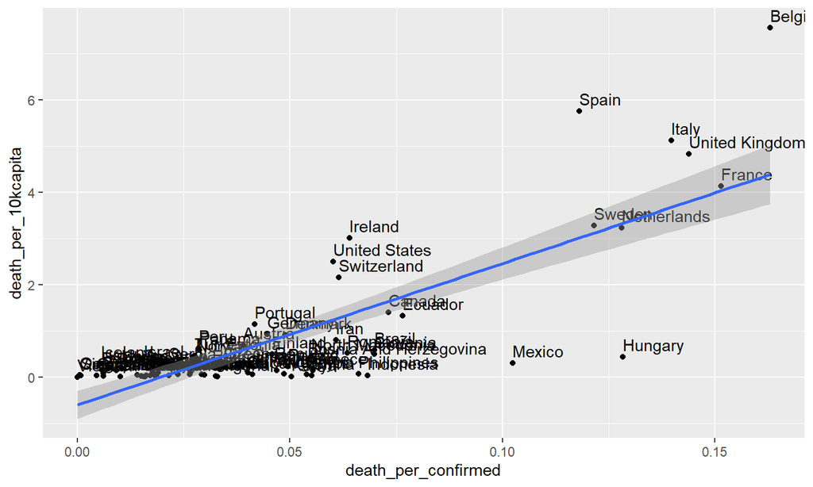

```r
ggplot(df, aes(x= death_per_confirmed, y= death_per_10kcapita)) +
                  geom_point() +
                  geom_text(aes(label=country),hjust=0, vjust=-0.5) +
                  geom_smooth(method='lm', formula= y  ~ x )
```

## Analysis of death per confirmed cases

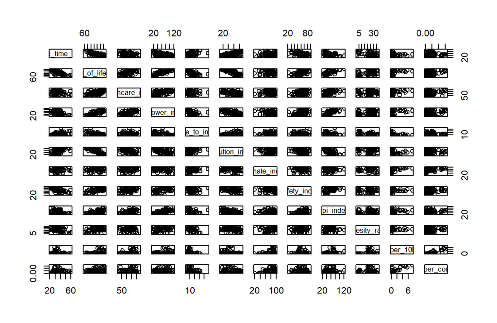

```r
pair_var <- c(2:5, 7:12, 17, 18)
pairs(df[pair_var])
```

Judging by these pair plots, it looks like the most interesting correlations for death rates among confirmed cases might be cpi_index, quality_of_life_index, climate_index, obesity_rate, and possibly pollution_index and healthcare_index

## Death Per Confirmed Cases Overview

The countries with the 20 highest deaths per confirmed cases:

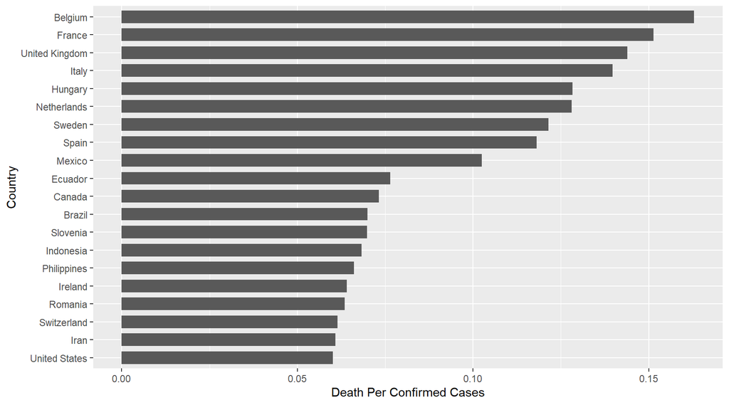

## Analysis of death per confirmed cases (cont’d)

We run regressions on ourvariables of interest to look for a correlation

```r
m_health <- lm(death_per_confirmed ~ healthcare_index, df)
#summary(m_health)
m_pol <- lm(death_per_confirmed ~ pollution_index, df)
#summary(m_pol)
m_qol <- lm(death_per_confirmed ~ quality_of_life_index, df)
#summary(m_qol)
m_clim <- lm(death_per_confirmed ~ climate_index, df)
#summary(m_clim)
m_obes <- lm(death_per_confirmed ~ obesity_rate, df)
#summary(m_obes)
m_cpi <- lm(death_per_confirmed ~ cpi_index, df)
#summary(m_cpi)
```

## Deaths per confirmed cases vs Climate index

It seems like climate index is the only variable that has any statistical significance at all. Let’s take a closer look at that.

```r
summary(m_clim)
```

```
##
## Call:
## lm(formula = death_per_confirmed ~ climate_index, data = df)
##
## Residuals:
##       Min        1Q    Median        3Q       Max
## -0.044466 -0.026360 -0.008768  0.010994  0.111837
##
## Coefficients:
##                 Estimate Std. Error t value Pr(>|t|)
## (Intercept)   -0.0163938  0.0194277  -0.844  0.40138
## climate_index  0.0007845  0.0002459   3.191  0.00205 **
## ---
## Signif. codes:  0 '***' 0.001 '**' 0.01 '*' 0.05 '.' 0.1 ' ' 1
##
## Residual standard error: 0.03607 on 77 degrees of freedom
##   (1 observation deleted due to missingness)
## Multiple R-squared:  0.1168, Adjusted R-squared:  0.1053
## F-statistic: 10.18 on 1 and 77 DF,  p-value: 0.002054
```

## Deaths per confirmed cases vs Climate index

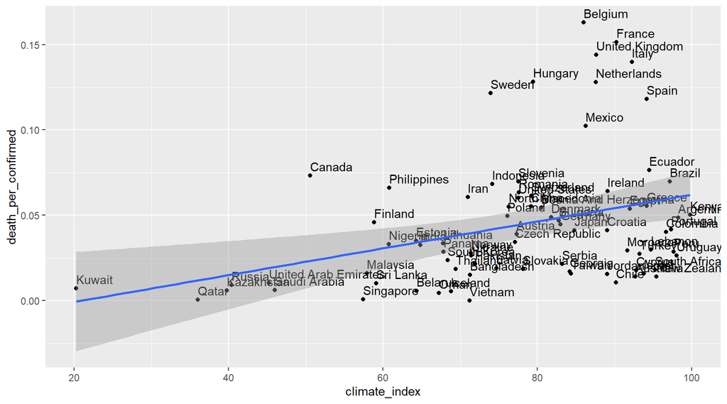

## Deaths per confirmed cases vs Climate index

This suggests that climate may have an effect on death rates. However, Numbeo’s climate index statistic is not an average temperature, but rather a “climate-likability” index, meaning it is more along the lines of a probability that the average person will enjoy this climate. Thus, warm but temperate climates are more likely to score higher, whereas more extreme or uncomfortable climates score lower. So this could either mean that the virus may be less lethal in more extreme climates, or it could be that death rates are higher in areas people are more likely to live.

## Death Per Capita Overview

The countries with the 20 highest deaths per capita:

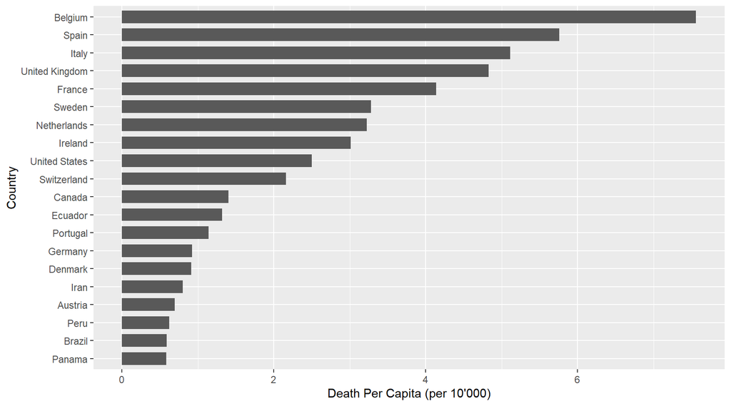

## Analysis of Death Per Capita

We repeat the analysis of death per confirmed case with deaths per capita (per 10’000 inhabitants), fitting it to various country indicators:

```r
m_health2 <- lm(death_per_10kcapita ~ healthcare_index, df)
#summary(m_health2)

m_pol2 <- lm(death_per_10kcapita ~ pollution_index, df)
#summary(m_pol2)

m_qol2 <- lm(death_per_10kcapita ~ quality_of_life_index, df)
#summary(m_qol2)

m_clim2 <- lm(death_per_10kcapita ~ climate_index, df)
#summary(m_clim2)

m_obes2 <- lm(death_per_10kcapita ~ obesity_rate, df)
#summary(m_obes2)

m_cpi2 <- lm(death_per_10kcapita ~ cpi_index, df)
#summary(m_cpi2)

m_purchpower2 <- lm(death_per_10kcapita ~ purchasing_power_incl_rent_index, df)
#summary(m_purchpower2)
```

## Purchasing Power vs Death Per Capita Summary

Purchasing Power has the largest adjusted R squared amongst the models with ~12%.

```r
summary(m_purchpower2)
```

```
##
## Call:
## lm(formula = death_per_10kcapita ~ purchasing_power_incl_rent_index,
##     data = df)
##
## Residuals:
##     Min      1Q  Median      3Q     Max
## -1.7110 -0.6440 -0.2418  0.0232  6.2927
##
## Coefficients:
##                                   Estimate Std. Error t value Pr(>|t|)
## (Intercept)                      -0.407562   0.372641  -1.094  0.27749
## purchasing_power_incl_rent_index  0.019404   0.005689   3.411  0.00104 **
## ---
## Signif. codes:  0 '***' 0.001 '**' 0.01 '*' 0.05 '.' 0.1 ' ' 1
##
## Residual standard error: 1.365 on 77 degrees of freedom
##   (1 observation deleted due to missingness)
## Multiple R-squared:  0.1312, Adjusted R-squared:   0.12
## F-statistic: 11.63 on 1 and 77 DF,  p-value: 0.001035
```

## Purchasing Power vs Death Per Capita Graph

As we saw in the summary output table there is a positive correlation between Purchasing Power and deaths per capita. This is somewhat counter-intuitive but looking at the countries in the top right corner we can see that “wealthier” Western countries are pulling up the regression.

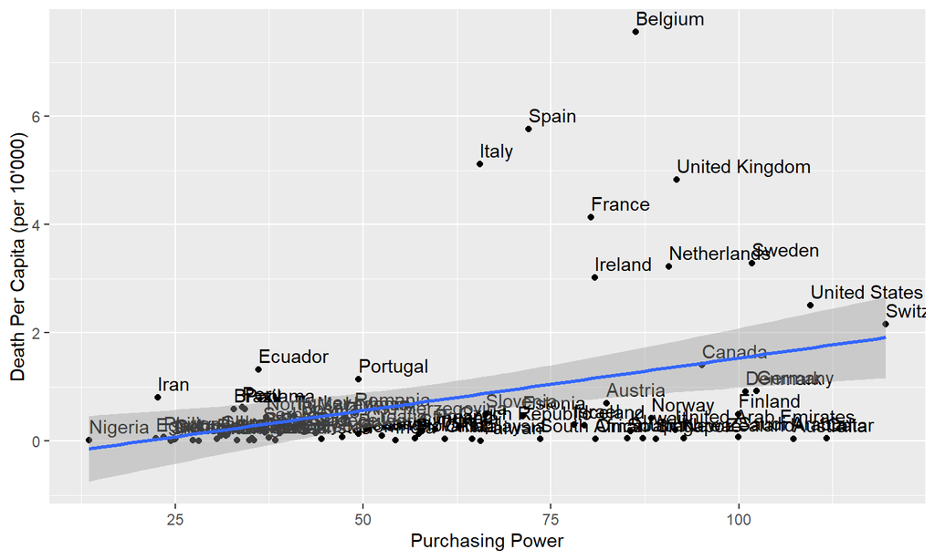

## Health Care vs Death Per Capita Summary

Health Care Rating has an adjusted R squared of ~7%, therefore, explains only very little of the variability of the death per capita.

```r
summary(m_health2)
```

```
##
## Call:
## lm(formula = death_per_10kcapita ~ healthcare_index, data = df)
##
## Residuals:
##     Min      1Q  Median      3Q     Max
## -1.6848 -0.7279 -0.4301  0.1171  6.4016
##
## Coefficients:
##                  Estimate Std. Error t value Pr(>|t|)
## (Intercept)      -2.02526    1.05006  -1.929  0.05745 .
## healthcare_index  0.04282    0.01601   2.674  0.00916 **
## ---
## Signif. codes:  0 '***' 0.001 '**' 0.01 '*' 0.05 '.' 0.1 ' ' 1
##
## Residual standard error: 1.401 on 77 degrees of freedom
##   (1 observation deleted due to missingness)
## Multiple R-squared:  0.08495,    Adjusted R-squared:  0.07307
## F-statistic: 7.148 on 1 and 77 DF,  p-value: 0.009157
```

## Health Care vs Death Per Capita Graph

Similar to the purchasing power also the health care rating looks to be positively correlated to death per capita. It, therefore, seems that the quality of the health care is not as important factors in estimating the death per capita.

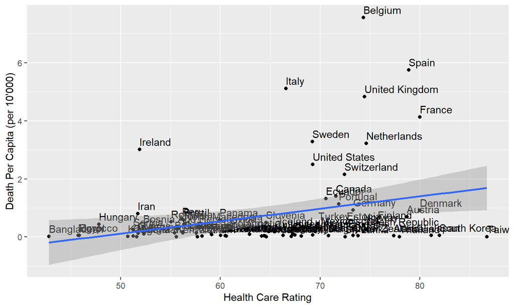

## Conclusion

We can see that, contrary to what we would have anticipated, we have a positive correlation between health care rating and the deaths per capita. The countries that stick out especially are Belgium, Spain, Italy, the UK and France. They all have a death per capita of more than 4 per 10 thousand. while having a relatively well rated health care system.

```r
head(arrange(df, desc(healthcare_index))[,c(1,4,17)])
```

```
##       country healthcare_index death_per_10kcapita
## 1      Taiwan         86.71453         0.002939105
## 2 South Korea         81.96500         0.050517676
## 3       Japan         81.14303         0.051946426
## 4     Denmark         79.99861         0.909843802
## 5      France         79.98899         4.135521312
## 6       Spain         78.88316         5.757699699
```